# TP2: Temporal model structure

About RWs and AR

Author

Lionel Hertzog

Published

April 7, 2026

```r
library(tidyverse)
library(INLA)
library(inlabru)
library(DHARMa)
```

**NoteObjective**

For this TP we will use a dataset of air quality measurements in Beijing across 12 stations. The full datasets is available from here: https://archive.ics.uci.edu/dataset/501/beijing+multi+site+air+quality+data. Here we will focus on modelling daily Ozone (O3) measures, the aim being to develop a model able to reproduce the temporal dynamics in Ozone and identify the impact of various meteorological parameters.

## 1 Metadata

To develop the model we will first focus on one station: “Dingling”.

```r
dingling <- read.csv("airdata/Dingling.csv")
# format the date column
dingling$date <- as.Date(dingling$date)
summary(dingling)
```

```
      year          month             day          station
 Min.   :2013   Min.   : 1.000   Min.   : 1.00   Length:1447
 1st Qu.:2014   1st Qu.: 4.000   1st Qu.: 8.00   Class :character
 Median :2015   Median : 6.000   Median :16.00   Mode  :character
 Mean   :2015   Mean   : 6.518   Mean   :15.79
 3rd Qu.:2016   3rd Qu.:10.000   3rd Qu.:23.00
 Max.   :2017   Max.   :12.000   Max.   :31.00
       O3              TEMP              PRES             DEWP
 Min.   :  1.00   Min.   :-14.958   Min.   : 985.8   Min.   :-32.229
 1st Qu.: 40.36   1st Qu.:  3.179   1st Qu.: 999.4   1st Qu.:-10.608
 Median : 66.17   Median : 14.775   Median :1007.7   Median :  1.350
 Mean   : 68.68   Mean   : 13.541   Mean   :1007.9   Mean   :  1.328
 3rd Qu.: 90.04   3rd Qu.: 23.444   3rd Qu.:1016.1   3rd Qu.: 13.883
 Max.   :289.50   Max.   : 32.367   Max.   :1034.9   Max.   : 26.000
      RAIN              WSPM             date
 Min.   :0.00000   Min.   :0.4542   Min.   :2013-03-01
 1st Qu.:0.00000   1st Qu.:1.3042   1st Qu.:2014-02-27
 Median :0.00000   Median :1.6375   Median :2015-02-26
 Mean   :0.06037   Mean   :1.8547   Mean   :2015-02-26
 3rd Qu.:0.00000   3rd Qu.:2.1688   3rd Qu.:2016-02-22
 Max.   :6.70833   Max.   :7.2375   Max.   :2017-02-28
```

```r
str(dingling)
```

```
'data.frame':   1447 obs. of  11 variables:
 $ year   : int  2013 2013 2013 2013 2013 2013 2013 2013 2013 2013 ...
 $ month  : int  3 3 3 3 3 3 3 3 3 3 ...
 $ day    : int  1 2 3 4 5 6 7 8 9 10 ...
 $ station: chr  "Dingling" "Dingling" "Dingling" "Dingling" ...
 $ O3     : num  82 24.7 41 76.9 86.5 ...
 $ TEMP   : num  0.812 -0.396 5.329 9.238 6.463 ...
 $ PRES   : num  1024 1024 1011 1014 1008 ...
 $ DEWP   : num  -19.6 -16.1 -13 -13.5 -9 ...
 $ RAIN   : num  0 0 0 0 0 0 0 0 0 0 ...
 $ WSPM   : num  2.133 0.929 1.363 2.383 0.767 ...
 $ date   : Date, format: "2013-03-01" "2013-03-02" ...
```

## 2 Data Exploration

### 2.1 Descriptice stats

Explore the data, looking at descriptive statistics of the various variables: mean, sd, range and making bivariate plots of Ozone against Date and the other variables.

Do you find interesting relations? What is the temporal dynamics of the Ozone levels?

**TipAnswer**

We can use ggplot to make the bivariate plots:

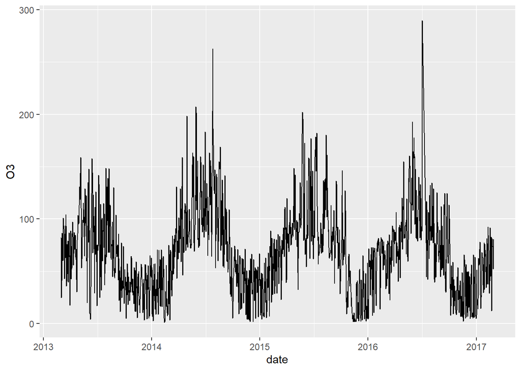

```r
ggplot(dingling, aes(x = date, y = O3)) +
  geom_path()
```

## 3 Model fitting - time only

### 3.1

Fit a first model in inlabru with as response the Ozone levels and a temporal structure that you can choose (AR1, RW1, RW2, a combination of these elements).

Choose an appropriate distribution for the response.

Take care 1: The temporal components should be based on time ID as integer, you need to create a new variable in the dataset.

**TipAnswer**

Here is an example with a RW2 + AR1 structure and a lognormal distribution with fixed residual sd.

```r
dingling$time_id <- as.integer(dingling$date)
m_time <- bru(O3 ~ Intercept(1) + temp_ar1(time_id, model = "ar1") + temp_rw2(time_id, model = "rw2"), data = dingling, family = "lognormal", control.family = list(hyper = list(prec = list(fixed = TRUE))))
summary(m_time)
```

```
inlabru version: 2.13.0
INLA version: 25.06.07
Components:
Intercept: main = linear(1), group = exchangeable(1L), replicate = iid(1L), NULL
temp_ar1: main = ar1(time_id), group = exchangeable(1L), replicate = iid(1L), NULL
temp_rw2: main = rw2(time_id), group = exchangeable(1L), replicate = iid(1L), NULL
Observation models:
  Family: 'lognormal'
    Tag: <No tag>
    Data class: 'data.frame'
    Response class: 'numeric'
    Predictor: O3 ~ .
    Additive/Linear: TRUE/TRUE
    Used components: effects[Intercept, temp_ar1, temp_rw2], latent[]
Time used:
    Pre = 0.722, Running = 1.13, Post = 0.956, Total = 2.81
Fixed effects:
           mean    sd 0.025quant 0.5quant 0.975quant  mode kld
Intercept 3.974 0.026      3.922    3.974      4.025 3.974   0

Random effects:
  Name    Model
    temp_ar1 AR1 model
   temp_rw2 RW2 model

Model hyperparameters:
                           mean       sd 0.025quant 0.5quant 0.975quant
Precision for temp_ar1 2.30e+04 25128.47   1656.237 1.52e+04   8.96e+04
Rho for temp_ar1       7.00e-03     0.70     -0.988 1.50e-02   9.88e-01
Precision for temp_rw2 9.53e+04 28779.73  50503.264 9.14e+04   1.63e+05
                            mode
Precision for temp_ar1  4566.956
Rho for temp_ar1          -0.998
Precision for temp_rw2 84144.380

Marginal log-Likelihood:  -7409.50
 is computed
Posterior summaries for the linear predictor and the fitted values are computed
(Posterior marginals needs also 'control.compute=list(return.marginals.predictor=TRUE)')
```

## 4 Plots of temporal dynamics

Plot (i) the fitted temporal dynamics with the 95% CI and (ii) the residuals against time to get a view of the dynamics of anomalies. What elements do you take out from these graphs?

**TipAnswer 1**

Here is how to get the fitted temporal dynamic using the predict function (note the use of exp to get back to the scale of measurement):

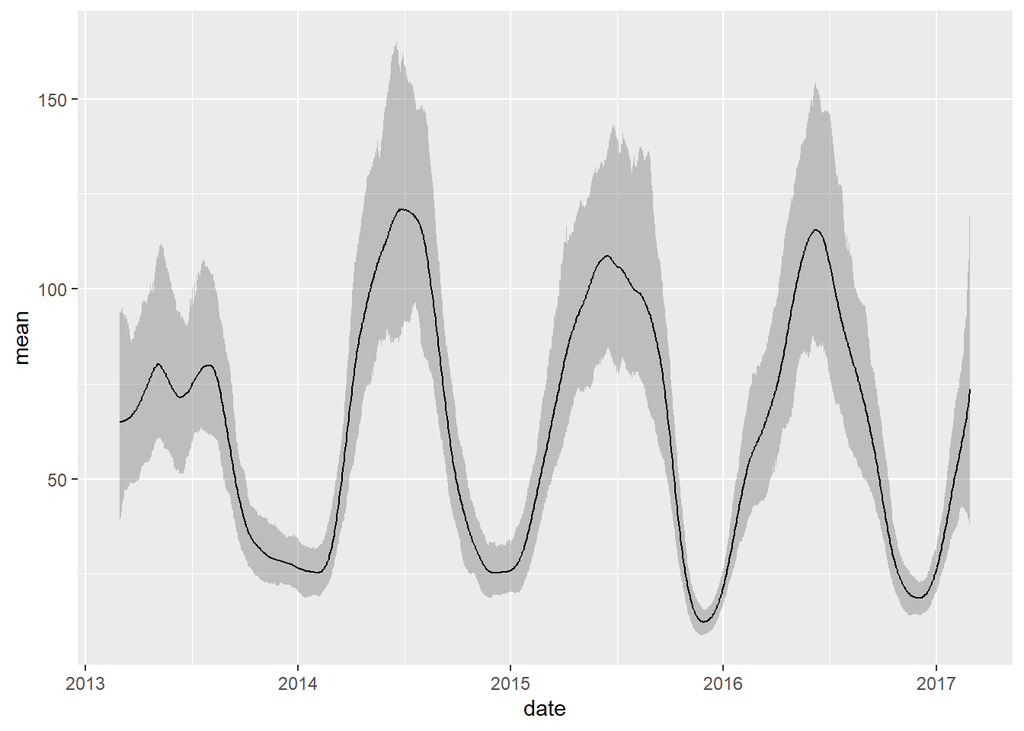

```r
pred <- predict(m_time, dingling, ~ exp(Intercept + temp_ar1 + temp_rw2))

ggplot(pred, aes(x=date, y=mean, ymin = q0.025, ymax = q0.975)) +
  geom_ribbon(alpha = 0.25) +
  geom_path()
```

**TipAnswer 2**

Here is how to get the residuals and plot them:

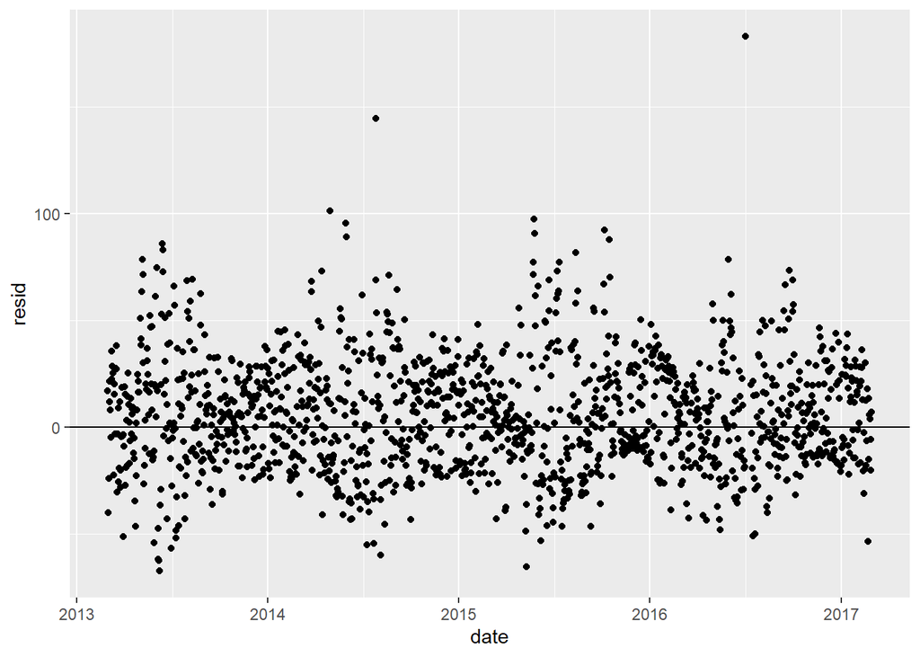

```r
pred$resid <- pred$O3 - pred$mean

ggplot(pred, aes(x=date, y=resid)) +
  geom_point() +
  geom_hline(yintercept = 0)
```

Bonus question: If you fitted a model with different temporal components, plot the temporal dynamics of these components separately.

**TipHint bonus**

Here is how this is done:

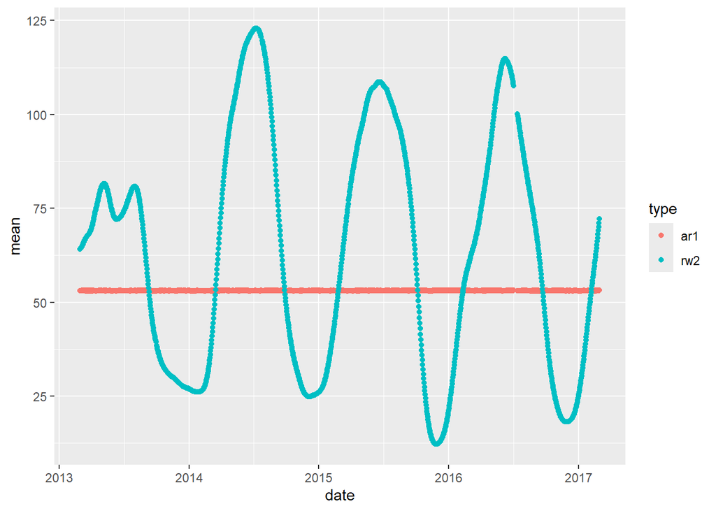

```r
pred_ar1 <- predict(m_time, dingling, ~ exp(Intercept + temp_ar1))
pred_rw2 <- predict(m_time, dingling, ~ exp(Intercept + temp_rw2))

# combine
pred_all <- rbind(select(pred_ar1, date, mean, q0.025, q0.975),
                  select(pred_rw2, date, mean, q0.025, q0.975))
pred_all$type <- rep(c("ar1", "rw2"), each = nrow(dingling))

ggplot(pred_all, aes(x=date, y=mean, color = type)) +
  geom_point()
```

### 4.1

Add weakly informative PC prior the temporal components.

Also check other settings or if interested other prior distribution like `gamma` or `logtnormal`.

**TipAnswer**

```r
m_time <- bru(O3 ~ Intercept(1) + temp_rw2(time_id, model = "rw2", hyper = list(prec = list(prior = "pc.prec", param = c(1, 0.01)))), data = dingling, family = "lognormal")
summary(m_time)
```

[output not shown]

Did this affect the estimated hyperparameters of the temporal effect? Plot the new predicted temporal dynamic and compare with the previous one.

### 4.2

Now run model checks using DHARMa, is the model ok? How would you improve/ modify this model?

**TipAnswer**

Here is how it can be done:

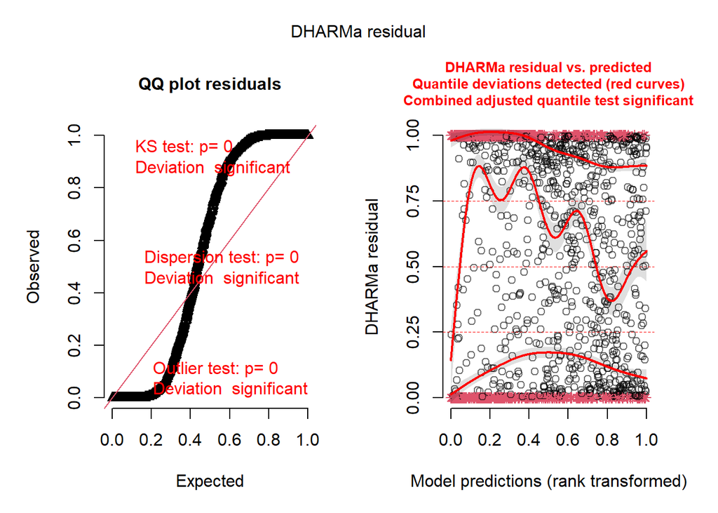

```r
## generate sims for DHARMa
sims <- generate(m_time, dingling, ~ rlnorm(n = nrow(dingling),
                                            meanlog = Intercept + temp_rw2,
                                            sdlog = 1/sqrt(m_time$summary.hyperpar$mean[1])), n.samples = 250)

ch_mtime <- createDHARMa(sims, dingling$O3)

plot(ch_mtime)
```

## 5 Model fitting - with meteo

### 5.1

Now we want to expand the model by adding meteorological factors. Construct a model with additional covariates from the available one.

**TipAnswer**

Here is how it can be done:

```r
# first I std the covariates for easier interpretation of effects
dingling_std <- mutate(dingling, across(TEMP:WSPM, scale))

m_meteo <- bru(O3 ~ Intercept(1) + TEMP + WSPM + PRES + DEWP + RAIN + temp_rw2(time_id, model = "rw2", hyper = list(prec = list(prior = "pc.prec", param = c(50, 0.01)))),  data = dingling_std, family = "normal")
summary(m_meteo)
```

```
inlabru version: 2.13.0
INLA version: 25.06.07
Components:
Intercept: main = linear(1), group = exchangeable(1L), replicate = iid(1L), NULL
TEMP: main = linear(TEMP), group = exchangeable(1L), replicate = iid(1L), NULL
WSPM: main = linear(WSPM), group = exchangeable(1L), replicate = iid(1L), NULL
PRES: main = linear(PRES), group = exchangeable(1L), replicate = iid(1L), NULL
DEWP: main = linear(DEWP), group = exchangeable(1L), replicate = iid(1L), NULL
RAIN: main = linear(RAIN), group = exchangeable(1L), replicate = iid(1L), NULL
temp_rw2: main = rw2(time_id), group = exchangeable(1L), replicate = iid(1L), NULL
Observation models:
  Family: 'normal'
    Tag: <No tag>
    Data class: 'data.frame'
    Response class: 'numeric'
    Predictor: O3 ~ .
    Additive/Linear: TRUE/TRUE
    Used components: effects[Intercept, TEMP, WSPM, PRES, DEWP, RAIN, temp_rw2], latent[]
Time used:
    Pre = 0.621, Running = 0.662, Post = 0.699, Total = 1.98
Fixed effects:
            mean    sd 0.025quant 0.5quant 0.975quant   mode kld
Intercept 68.652 0.612     67.451   68.652     69.853 68.652   0
TEMP      42.513 2.459     37.692   42.512     47.335 42.512   0
WSPM       8.149 0.818      6.545    8.149      9.753  8.149   0
PRES      10.077 1.452      7.228   10.078     12.922 10.078   0
DEWP      -2.686 2.047     -6.702   -2.685      1.327 -2.685   0
RAIN      -0.785 0.659     -2.078   -0.785      0.508 -0.785   0

Random effects:
  Name    Model
    temp_rw2 RW2 model

Model hyperparameters:
                                           mean    sd 0.025quant 0.5quant
Precision for the Gaussian observations   0.002  0.00      0.002    0.002
Precision for temp_rw2                  129.996 27.58     83.574  127.354
                                        0.975quant    mode
Precision for the Gaussian observations      0.002   0.002
Precision for temp_rw2                     191.621 122.486

Marginal log-Likelihood:  -6726.45
 is computed
Posterior summaries for the linear predictor and the fitted values are computed
(Posterior marginals needs also 'control.compute=list(return.marginals.predictor=TRUE)')
```

### 5.2

Perform standard model checks on this model and explore variations if needed.

### 5.3

Plot the predicted temporal dynamics with and without taking into account the meteorological parameters.

**TipAnswer**

Here is how it can be done:

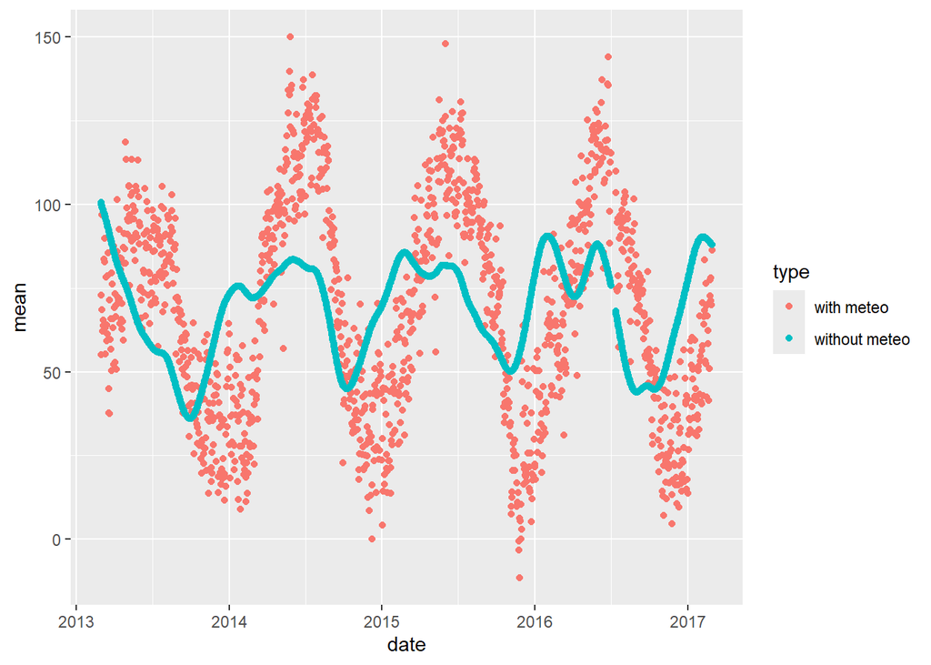

```r
## generate the model predictions with and without
pred_with <- predict(m_meteo, dingling_std, ~ Intercept + temp_rw2 + TEMP + WSPM + PRES + DEWP + RAIN)
pred_without <- predict(m_meteo, dingling_std, ~ Intercept + temp_rw2)

## combine
pred_comb <- rbind(select(pred_with, date, mean),
                   select(pred_without, date, mean))
pred_comb$type <- rep(c("with meteo", "without meteo"), each = nrow(dingling_std))

## plot
ggplot(pred_comb, aes(x = date, y = mean, color = type)) +
  geom_point()
```

Bonus: add to this plot the predicted dynamic form the model without meteorological parameters.

## 6

Bonus question: so far we worked on only one station, but we have data on 12. Develop a hierarchical model from all stations.